# Correlated Regressors

Joke Durnez

1/24/2018

# 1 Motivation

We have an fMRI design where we’re interested in the contrast between two regressors. After optimising the design, we end up with negatively correlated regressors. Negatively correlated regressors are a bad thing for linear models: they increase the variance of the estimators. So why does an optimisation result in high anticorrelations? Well, in this case we are only interested in the contrast between the two regressors. Negatively correlated regressors are only problematic if we’re interested in the estimates of the regressors, **not** if we’re only interested in the contrast. Even more: negatively correlated regressors are a positive thing in [1,-1] contrasts. Let’s look at a simulation.

**Intuitive example**

Here’s a very intuitive example. If you want to measure the influence of IQ on parental attachment, you want to have the extremes in your sample: either very low or very high IQ. If you’d include only people +/- 100, you’re looking for a tiny effect and you won’t learn as much from these ‘average’ people. In statistical terms, this means you want to have as much variance in your design as possible.

Now imagine you’re interested in the influence of the **difference** in IQ between a parent and their kid and their attachment. In this case, you want to include as much as people with large differences: smart parent / less smart kid and the opposite. Families where the difference is small are not going to tell you much about the influence of that difference. Like before, you want to increase the variance of the variable of interest. Only in this case, the variable of interest is the difference, and it’s maximised by increasing the anti-correlations.

# 2 Simulation

First we’ll make a few functions to simulate data and model the data using the contrasts (using the `multcomp` library).

## 2.1 Define and illustrate functions to simulate and model

### 2.1.1 Generate data

```r
library(MASS)
simulate <- function(correlation,ntp,betas){
  means <- c(0,0)
  Sigma <- matrix(c(1,correlation,correlation,1),nrow=2)
  regressors <- mvrnorm(n=ntp,means,Sigma)
  data <- data.frame(regressors)
  data$signal <- betas[1]*data$X1 + betas[2]*data$X2 + rnorm(ntp,0,1)
  data$index <- seq(ntp)
  data
}

# the data
data <- simulate(correlation = -0.8, ntp = 100, betas = c(0.5,-0.5))
head(data)
```

```
##           X1         X2     signal index
## 1 -0.4300979 -0.3620275 -0.6959136     1
## 2  0.9386404 -1.0338989  2.3593342     2
## 3  0.9445594 -0.7725494  1.1251257     3
## 4 -1.7789770  2.0025861  1.2015261     4
## 5 -1.5928781  1.0526745 -2.5134325     5
## 6  1.1727227 -1.7620167  1.0683069     6
```

```r
# the correlation matrix
print(cor(data[,1:2]))
```

```
##            X1         X2
## X1  1.0000000 -0.7490413
## X2 -0.7490413  1.0000000
```

In the figure below, we can clearly see the high anticorrelations.

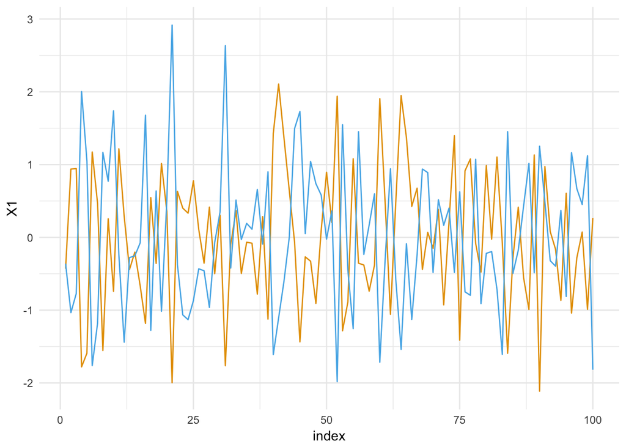

```r
library(ggplot2)
library(ggthemes)
cbPalette <- c("#999999", "#E69F00", "#56B4E9", "#009E73", "#F0E442", "#0072B2", "#D55E00", "#CC79A7")
ggplot(data,aes(x=index)) +
  geom_line(aes(y=X1),col=cbPalette[2]) +
  geom_line(aes(y=X2),col=cbPalette[3]) +
  scale_fill_manual(values=cbPalette) +
  theme_minimal()
```

### 2.1.2 Model data

Let’s also define a function to compute the contrast:

```r
library(multcomp)
library(viridis)
```

```r
lm_contrast <- function(data,contrast){
  fit <- lm(signal~X1+X2, data=data)
  cfit <- glht(fit,linfct=contrast)
  tstat <- summary(cfit)$test$tstat
  tstat
}

# for example...
contrast <- matrix(c(0,1,-1),nrow=1)
print(contrast)
```

```
##      [,1] [,2] [,3]
## [1,]    0    1   -1
```

```r
tval <- lm_contrast(data,contrast)
print(paste("The resulting T-value is",tval))
```

```
## [1] "The resulting T-value is 8.64642454597488"
```

While we’re at it, we can also make a new function to compute the T-statistic from a model with 1 regressor: the difference between the two anticorrelated regressors:

```r
lm_diff <- function(data){
  data$Xdif <- data$X1-data$X2
  dfit <- lm(signal~Xdif, data=data)
  tstat <- summary(dfit)$coefficients[2,3]
  tstat
}

# for example...
tval <- lm_diff(data)
print(paste("The resulting T-value is",tval))
```

```
## [1] "The resulting T-value is 8.82487692017368"
```

## 2.2 Simulations

### 2.2.1 Simulation 1: anticorrelations and contrast (1,-1)

First set parameters:

```r
cors <- seq(from=-0.1,to=-0.9,by=-0.1)
nsim <- 5000
ntp <- 100
betas <- c(0.5,-0.5)
contrast <- matrix(c(0,1,-1),nrow=1)
```

Now simulate the data within a loop of correlation values.

```r
results <- data.frame(
  correlation=numeric(length(cors)*nsim),
  simulation=numeric(length(cors)*nsim),
  Tc=numeric(length(cors)*nsim),
  Td = numeric(length(cors)*nsim)
)

k <- 0
for (correlation in cors){
  for (s in 1:nsim){
    k = k+1
    data <- simulate(correlation=correlation,ntp=ntp,betas = betas)
    results$correlation[k] <- correlation
    results$simulation[k] <- s
    results$Tc[k] <- lm_contrast(data,contrast)
    results$Td[k] <- lm_diff(data)
  }
  print(paste("mean of correlation ",correlation," = ",mean(results$Tc[results$correlation==correlation])))
}
```

```
## [1] "mean of correlation  -0.1  =  7.37500424916928"
## [1] "mean of correlation  -0.2  =  7.70246167460223"
## [1] "mean of correlation  -0.3  =  8.00438087589409"
## [1] "mean of correlation  -0.4  =  8.29960791223447"
## [1] "mean of correlation  -0.5  =  8.61574748332354"
## [1] "mean of correlation  -0.6  =  8.91241269825031"
## [1] "mean of correlation  -0.7  =  9.15737889867012"
## [1] "mean of correlation  -0.8  =  9.45272570366235"
## [1] "mean of correlation  -0.9  =  9.69612752408162"
```

Let’s take a look at the (alternative) distribution of the obtained T-values wrt the correlations.

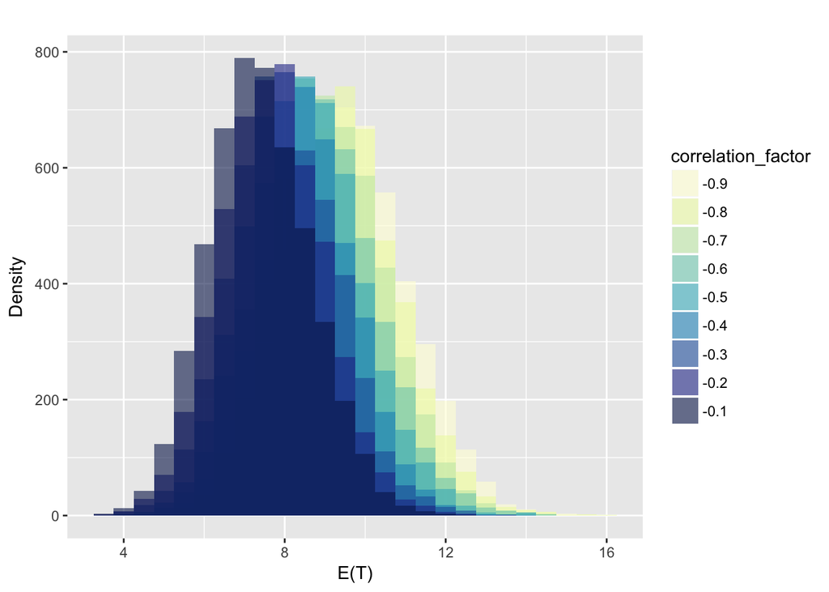

```r
results$correlation_factor <- factor(results$correlation)

ggplot(results,aes(x=Tc,fill=correlation_factor,aes(factor(correlation_factor)))) +
  geom_histogram(aes(y=..count..,fill=correlation_factor),binwidth=0.5,alpha=0.6,position='identity') +
  scale_fill_brewer(palette='YlGnBu') +
  labs(x='E(T)',y='Density',title='')
```

### 2.2.2 Simulation 2: anticorrelations and contrast (1,0)

Now it’s also fairly easy to take a look at when we’re only interested in the main effect (regressor vs baseline):

```r
contrast <- matrix(c(0,1,0),nrow=1)

results_main <- data.frame(
  correlation=numeric(length(cors)*nsim),
  simulation=numeric(length(cors)*nsim),
  Tc=numeric(length(cors)*nsim))

k <- 0
for (correlation in cors){
  for (s in 1:nsim){
    k = k+1
    data <- simulate(correlation=correlation,ntp=ntp,betas = betas)
    results_main$correlation[k] <- correlation
    results_main$simulation[k] <- s
    results_main$Tc[k] <- lm_contrast(data,contrast)
  }
  print(paste("mean of correlation ",correlation," = ",mean(results_main$Tc[results_main$correlation==correlation])))
}
```

```
## [1] "mean of correlation  -0.1  =  4.95165901912544"
## [1] "mean of correlation  -0.2  =  4.8625639146075"
## [1] "mean of correlation  -0.3  =  4.74919347249855"
## [1] "mean of correlation  -0.4  =  4.54505236988422"
## [1] "mean of correlation  -0.5  =  4.33437348384696"
## [1] "mean of correlation  -0.6  =  3.9975204664315"
## [1] "mean of correlation  -0.7  =  3.56680375910232"
## [1] "mean of correlation  -0.8  =  2.98951747926426"
## [1] "mean of correlation  -0.9  =  2.169862686831"
```

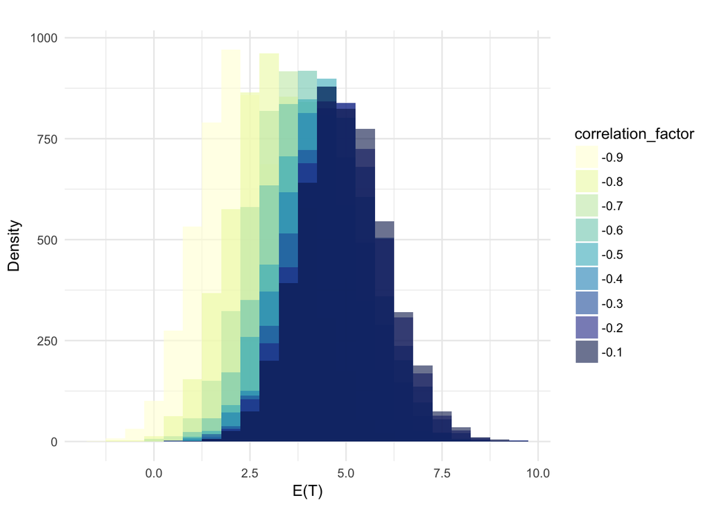

```r
results_main$correlation_factor <- factor(results_main$correlation)

ggplot(results_main,aes(x=Tc,fill=correlation_factor,aes(factor(correlation_factor)))) +
  geom_histogram(aes(y=..count..,fill=correlation_factor),binwidth=0.5,alpha=0.6,position='identity') +
  scale_fill_brewer(palette='YlGnBu') +
  labs(x='E(T)',y='Density',title='') +
    theme_minimal()
```

### 2.2.3 Modeling with (1-1) contrast vs modeling with difference (x1-x2)

We discussed whether it would make a difference if we model the data using contrasts, vs if we model directly the difference between the regressors. Turns out there’s not much of a difference.

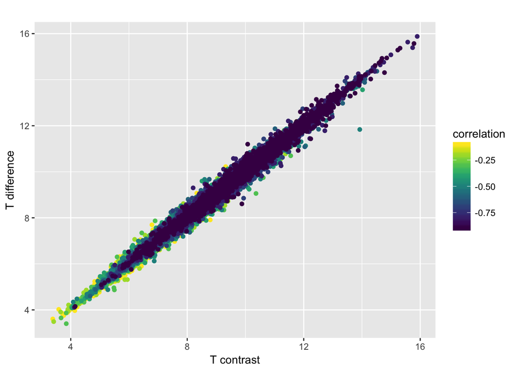

```r
ggplot(results,aes(x=Tc,y=Td,color=correlation,aes(correlation))) +
  geom_point() +
  scale_colour_viridis() +
  labs(x='T contrast',y='T difference',title='')
```

# 3 The math

This is how the T-statistic is computed when using contrasts:

$$T = \frac{c'\widehat{\beta}}{\sqrt{\sigma^2 c' (X'X)^{-1}c}}$$

Let’s especially look at this factor $c'(X'X)^{-1}c$, as this is the variable influenced by the design (i.e. the only one we can change). We want the T-statistic to be as large as possible, so **we want this factor to be as small as possible**.

## 3.1 Contrast [1,-1]

Let’s write it out for our specific example, with two regressors and [1,-1] contrast. $x_1$ and $x_2$ are the two regressors (in $X$). $\sigma_{x_i}^2$ is the variance of $x_i$, while $\sigma_{x_1x_2}$ is the covariance between the regressors and $\rho_{x_1x_2}$ the correlation between the regressors. We’ll assume the regressors are standardised, $N(0,1)$.

1. Inverse of $(X'X)^{-1}$

$$\begin{align}
c'(X'X)^{-1}c &= [1,-1]
\begin{bmatrix}
\sigma_{x_1}^2 & \sigma_{x_1x_2} \\
\sigma_{x_1x_2} & \sigma_{x_2}^2
\end{bmatrix}^{-1}
\begin{bmatrix}1 \\ -1\end{bmatrix} \\
&= [1,-1]
\begin{bmatrix}
1 & \rho_{x_1x_2} \\
\rho_{x_1x_2} & 1
\end{bmatrix}^{-1}
\begin{bmatrix}1 \\ -1\end{bmatrix} \\
&= [1,-1] \frac{1}{1 - \rho_{x_1x_2}^2}
\begin{bmatrix}
1 & -\rho_{x_1x_2} \\
-\rho_{x_1x_2} & 1
\end{bmatrix}\begin{bmatrix}1 \\ -1\end{bmatrix}
\end{align}$$

2. Work out contrasts

$$\begin{align}
c'(X'X)^{-1}c &= \frac{1}{1 - \rho_{x_1x_2}^2}
\left( [1,-1]
\begin{bmatrix}
1 & -\rho_{x_1x_2} \\
-\rho_{x_1x_2} & 1
\end{bmatrix}\begin{bmatrix}1 \\ -1\end{bmatrix} \right) \\
&= \frac{1}{1 - \rho_{x_1x_2}^2}
\begin{bmatrix}
1+\rho_{x_1x_2} & -\rho_{x_1x_2}-1
\end{bmatrix}
\begin{bmatrix}1 \\ -1\end{bmatrix} \\
&= \frac{2 + 2\rho_{x_1x_2}}{1 - \rho_{x_1x_2}^2}\\
\\
\end{align}$$

And as such, the denominator of the T-statistic equals:

$$\sqrt{\sigma^2 c' (X'X)^{-1}c} = \sqrt{\sigma^2 \frac{2 + 2\rho_{x_1x_2}}{1 - \rho_{x_1x_2}^2}}$$

And assuming $\sigma^2=1$, that function looks like the following plot. We see that the smaller the correlation (i.e. the closer to -1), the smaller the denominator in the $T$-statistic and consequently the larger the $T$-value and the power. **Conclusion: For this contrast, large anticorrelations are good.**

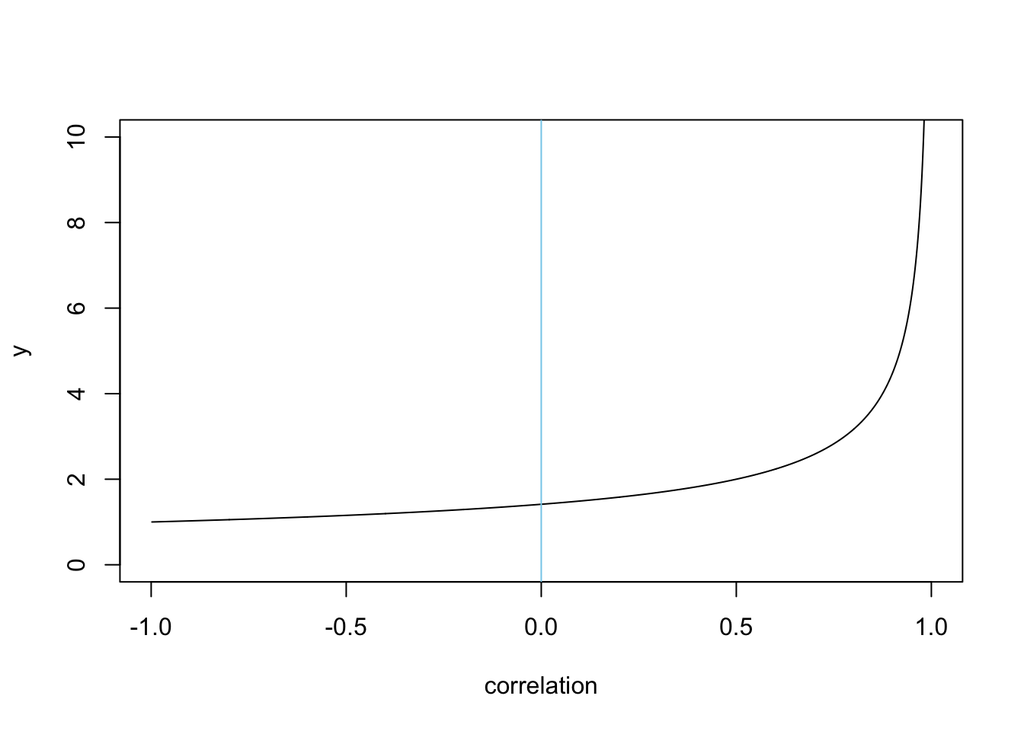

```r
x <- seq(from=-1,to=1,length=1000)
y <- sqrt((2+2*x)/(1-x^2))
plot(x,y,type='l',ylim=c(0,10),xlab='correlation',ylab='y')
abline(v=0,col='skyblue')
```

## 3.2 Contrast [1,0]

$$\begin{align}
c'(X'X)^{-1}c &= \frac{1}{1 - \rho_{x_1x_2}^2}
\left( [1,0]
\begin{bmatrix}
1 & -\rho_{x_1x_2} \\
-\rho_{x_1x_2} & 1
\end{bmatrix}\begin{bmatrix}1 \\ 0\end{bmatrix} \right) \\
&= \frac{1}{1 - \rho_{x_1x_2}^2}
\begin{bmatrix}
1 & -\rho_{x_1x_2}
\end{bmatrix}
\begin{bmatrix}1 \\ 0\end{bmatrix} \\
&= \frac{1}{1 - \rho_{x_1x_2}^2}\\
\\
\end{align}$$

And as such, the denominator of the T-statistic equals:

$$\sqrt{\sigma^2 c' (X'X)^{-1}c} = \sqrt{\frac{\sigma^2}{1 - \rho_{x_1x_2}^2}}$$

Again assuming $\sigma^2=1$, that function looks like the following plot. We see that the smaller the **absolute** correlation (i.e. the closer to 0), the smaller the denominator in the $T$-statistic and consequently the larger the $T$-value and the power. **Conclusion: For this contrast, large anticorrelations are bad.**

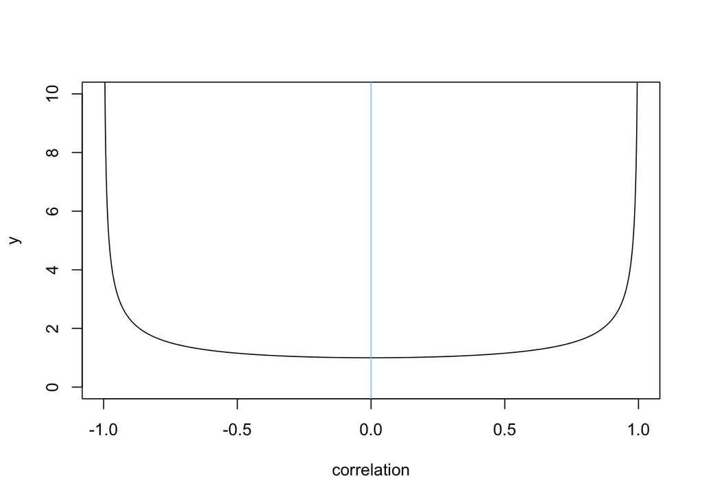

```r
x <- seq(from=-1,to=1,length=1000)
y <- sqrt(1/(1-x^2))
plot(x,y,type='l',ylim=c(0,10),xlab='correlation',ylab='y')
abline(v=0,col='skyblue')
```